# Rackman

Утилита, позволяющая измерять растояния в пикселях, миллиметрах, дюймах и пунктах Adobe на экране вашего монитора. Представляет собой два окна: 1. **главное** (*Master*), содержащее численную информацию и меню; 2. **дочернее** (*Slave*), представляющее собой некий измерительный инструмент.

Написана на Python и GTK.

## Размеры

Rackman позволяет измерять высоту и ширину объектов на экране.

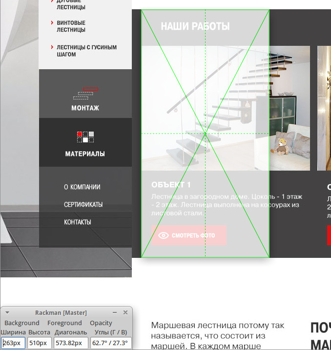

Измерение высоты

## Диагональ

Rackman позволяет измерять длину диагонали.

## Углы

Rackman позволяет измерять горизональные и вертикальные углы.

[figure not shown]

Измерение углов

## Центры

Rackman позволяет визуально отслеживать центрирование.

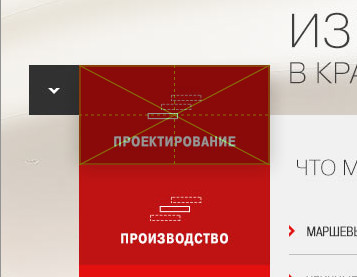

Центровка

## Управление дочерним окном измерения (Slave)

- Попиксельное изменение ширины и высоты окна
- `←`, `↑`, `→`, `↓`
- `Alt` + `←`, `↑`, `→`, `↓`
- Попиксельное перемещение окна
- `Ctrl` + `←`, `↑`, `→`, `↓`
- Быстрое изменение размеров и перемещение окна
- `Shift` + `←`, `↑`, `→`, `↓`
- `Shift` + `Ctrl` + `←`, `↑`, `→`, `↓`
- `Shift` + `Alt` + `←`, `↑`, `→`, `↓`
- используйте нативные методы вашего DE.

## Установка и запуск

### Stand-alone версия

```bash
# скачивание последней версии
$ wget https://github.com/FRiMN/Rackman/archive/master.zip
# распаковка
$ unzip master.zip
# переход в директорию
$ cd ./Rackman-master/
# установка прав на чтение и выполнение всем и на запись пользователю
$ chmod u=rwx,g=rx,o=rx rackman.py
# запуск Rackman
$ ./rackman.py
```

### Установка из репозиториев (только для Ubuntu)

```bash
$ sudo add-apt-repository ppa:freezemandix/rackman
$ sudo apt-get update
$ sudo apt-get install rackman
```

### ebuild для Gentoo

https://github.com/msva/mva-overlay/blob/master/x11-misc/rackman/rackman-9999.ebuild

## Известные баги и особенности

- Измеритель – обычное окно, со всеми вытекающими (например: нельзя померить в местах недоступных для размещения окон)
- Быстрое перемещение и изменение размера окна измерения полностью зависит от натроек вашего DE
- Если в вашем DE есть умное поведение окон (прилипание и т.п.), то оно будет применяться и к измерителю, что не всегда удобно
- Изменение цвета и прозрачности с клавиатуры работает только для Master-окна (окно должно быть в фокусе)
- Центральные прерывистые линии могут быть несколько размазаны при чётных высоте или ширине окна. Это особенности рендринга gtk и cairo линий располагающихся “между пикселей”
- Размеры по вертикали для производных единиц (все кроме px) могут быть несколько меньше реальных (~0.5mm)

## License

MIT License

## Authors

3. 2015-2019 Николай Волков

https://github.com/FRiMN/Rackman